# Oya-HW2

Oya Hoban - IE360 - Spring 2021

07 05 2021

# Homework 2

In this homework Consumer Price Index for Food and Non-Alcoholic Beverages have been inspected and tried to be predicted with respect to USD-TL Exchange Rate, Interest Rate, Total Consumer Credits and Consumer Trust Index datasets which are obtained from 2013 January to 2021 March. Since Consumer Price Index is an indicator for a fixed basket of good’s relative price over time, it gives an idea about overall price level of the economy. So, relevant dataset which effect the overall price level have been chosen in order to inspect how they correlate. Interest Rate, Exchange Rate and Total Consumer Credits are familiar concept that have been learned in Economics courses. And Consumer Trust Index is an measurement for consumers trust over the economy’s well-being.

For this homework,all datasets that have been extracted from [EVDS](https://evds2.tcmb.gov.tr/index.php) are examined.

## 1.1 Getting to Know the Data

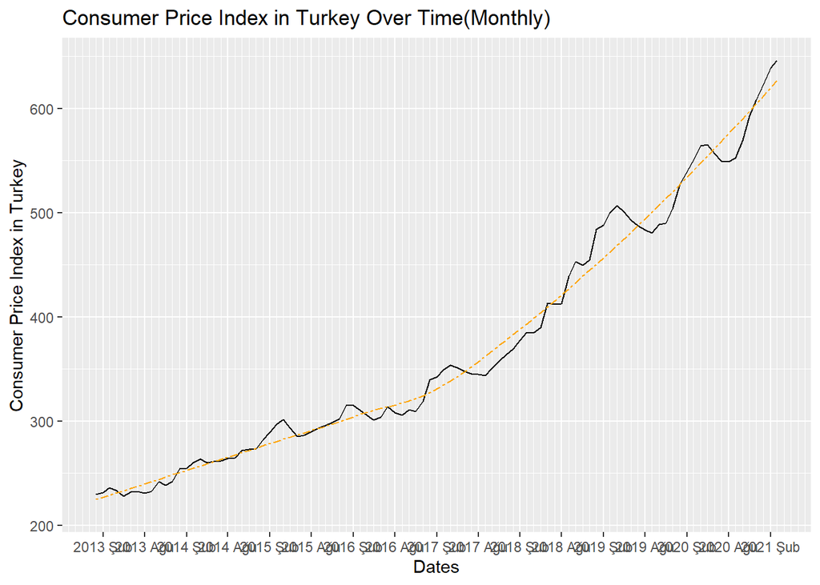

Figure 1.1- Consumer Price Index in Turkey Over Time

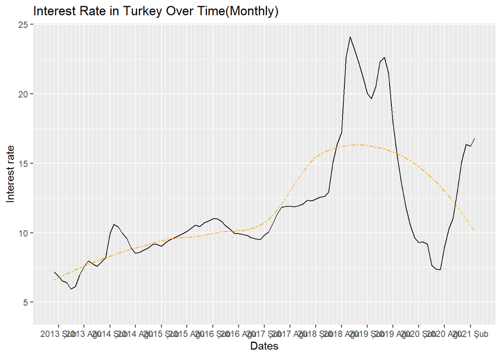

Figure 1.2- Interest Rate Over Time

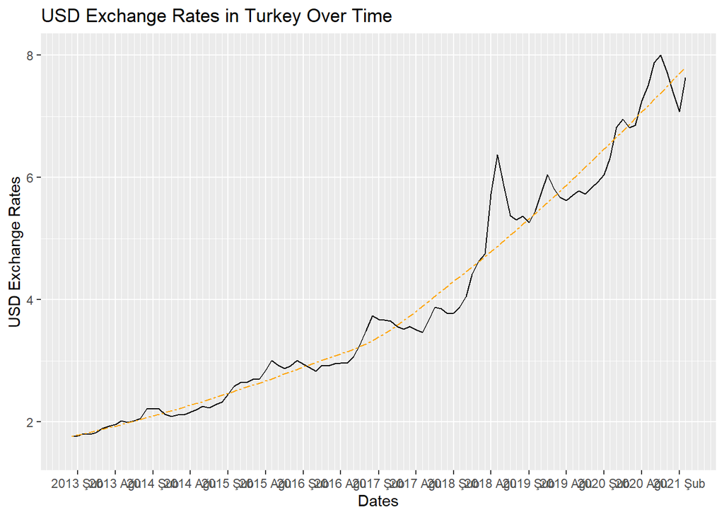

Figure 1.3- USD Exchange Rates in Turkey Over Time

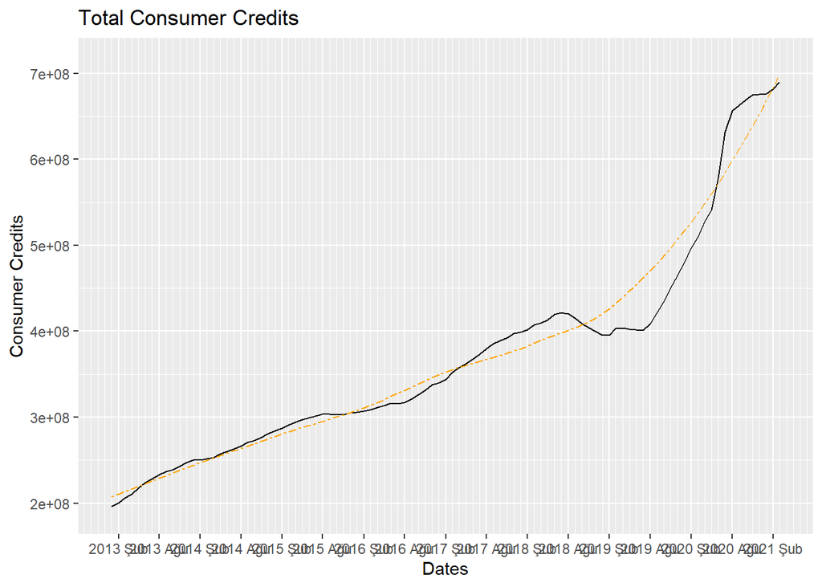

Figure 1.4- Total Consumer Credits Borrowed From Banks

[figure not shown]

Figure 1.5- Consmer Trust Index

After plotting the all the attributes over time, In Figure 1.1 we can see that CPI has an increasing trend over time, however some variations can be observed

In Figure 1.2, we can see that Interest Rate has a increasing trend from 2013 to 2018, but variations from trend line increases from 2018 to 2021.

In Figure 1.3, 1.4 and 1.5 we also see an increasing trend with variations from trend line. Variations increase in Figure 1.4 and 1.5 from 2018 to 2021, like it did in Interest Rate plot.

## 1.2 Generating Time Series Regression Models

```
##
## Call:
## lm(formula = CPI ~ USD + Interest_Rate + Cons_Credit + Trust_Index,
##     data = datatable_ts)
##
## Residuals:
##     Min      1Q  Median      3Q     Max
## -69.901  -7.470   2.245   6.510  50.583
##
## Coefficients:
##                 Estimate Std. Error t value Pr(>|t|)
## (Intercept)    2.317e+02  6.599e+01   3.511 0.000688 ***
## USD            4.390e+01  6.107e+00   7.187 1.56e-10 ***
## Interest_Rate  1.050e+00  6.658e-01   1.577 0.118207
## Cons_Credit    2.241e-07  6.917e-08   3.239 0.001656 **
## Trust_Index   -1.467e+00  7.083e-01  -2.071 0.041130 *
## ---
## Signif. codes:  0 '***' 0.001 '**' 0.01 '*' 0.05 '.' 0.1 ' ' 1
##
## Residual standard error: 19.83 on 94 degrees of freedom
## Multiple R-squared:  0.9725, Adjusted R-squared:  0.9714
## F-statistic: 832.1 on 4 and 94 DF,  p-value: < 2.2e-16
```

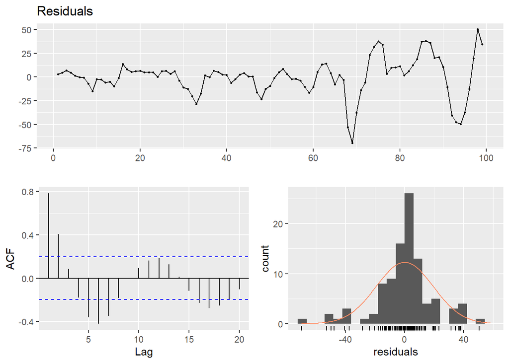

Residuals for Model 1

```
##
##  Breusch-Godfrey test for serial correlation of order up to 10
##
## data:  Residuals
## LM test = 77.229, df = 10, p-value = 1.749e-12
```

After checking the residuals’ plots, we can see some distortions from the zero mean from Index 60 to 100. Also, in there are high autocorrelation results as well, that we should eliminate. Also, looking at the histogram, the residuals don’t really fit the normally distributed shaped function. So, these are the issues to deal with for this model.

In section 1.1, CPI’s variations from the trend can be observed, and also Interest Rate has the largest variations from 2018 to 2021, these may be causing high residual errors and high autocorrelation. In order to decrease these variations a new data table is obtained with taking the square root of CPI and also taking thr logarithm of Interest Rate. And the model is built again, to see these variables correlations.

```
##
## Call:
## lm(formula = CPI_sqrt ~ USD + Cons_Credit + Trust_Index + Interest_Rate_log +
##     as.factor(month) + trend, data = datatable_ts_log)
##
## Residuals:
##      Min       1Q   Median       3Q      Max
## -0.76707 -0.18150  0.02495  0.19049  0.79993
##
## Coefficients:
##                      Estimate Std. Error t value Pr(>|t|)
## (Intercept)         1.621e+01  1.157e+00  14.016  < 2e-16 ***
## USD                 8.201e-01  1.047e-01   7.837 1.47e-11 ***
## Cons_Credit         1.775e-09  1.154e-09   1.538  0.12789
## Trust_Index        -3.404e-02  1.209e-02  -2.814  0.00612 **
## Interest_Rate_log   1.158e-01  1.512e-01   0.766  0.44573
## as.factor(month)2   9.498e-02  1.515e-01   0.627  0.53233
## as.factor(month)3   1.252e-01  1.507e-01   0.831  0.40851
## as.factor(month)4   3.802e-02  1.565e-01   0.243  0.80869
## as.factor(month)5  -1.706e-01  1.573e-01  -1.084  0.28144
## as.factor(month)6  -1.910e-01  1.567e-01  -1.219  0.22637
## as.factor(month)7  -2.656e-01  1.562e-01  -1.701  0.09275 .
## as.factor(month)8  -5.125e-01  1.561e-01  -3.283  0.00151 **
## as.factor(month)9  -6.579e-01  1.554e-01  -4.233 5.98e-05 ***
## as.factor(month)10 -5.048e-01  1.554e-01  -3.249  0.00168 **
## as.factor(month)11 -4.287e-01  1.556e-01  -2.755  0.00724 **
## as.factor(month)12 -3.583e-01  1.557e-01  -2.301  0.02391 *
## trend               3.783e-02  4.510e-03   8.386 1.20e-12 ***
## ---
## Signif. codes:  0 '***' 0.001 '**' 0.01 '*' 0.05 '.' 0.1 ' ' 1
##
## Residual standard error: 0.3194 on 82 degrees of freedom
## Multiple R-squared:  0.9902, Adjusted R-squared:  0.9883
## F-statistic: 518.1 on 16 and 82 DF,  p-value: < 2.2e-16
```

This time we see an Adjusted R-Squared Value =0.9883, we can say that model 2 is better than the model 1.

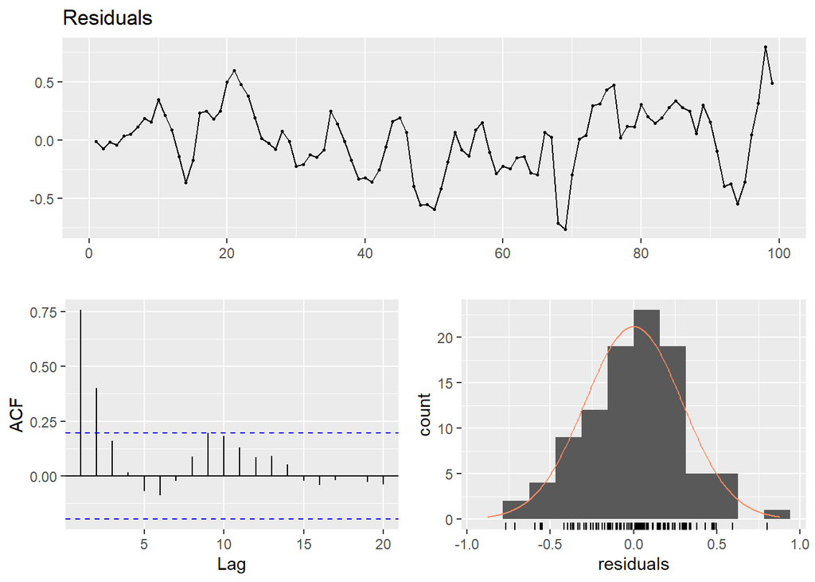

Residuals for Model 2

```
##
##  Breusch-Godfrey test for serial correlation of order up to 20
##
## data:  Residuals
## LM test = 75.021, df = 20, p-value = 2.703e-08
```

Looking at the residuals’ plots, residual errors have decreased, residuals’ distribution shape fits better in normal distribution’s shape, also high ACF generally eliminated, however there is still high ACF rate in lag1 and lag2 which should be eliminated.

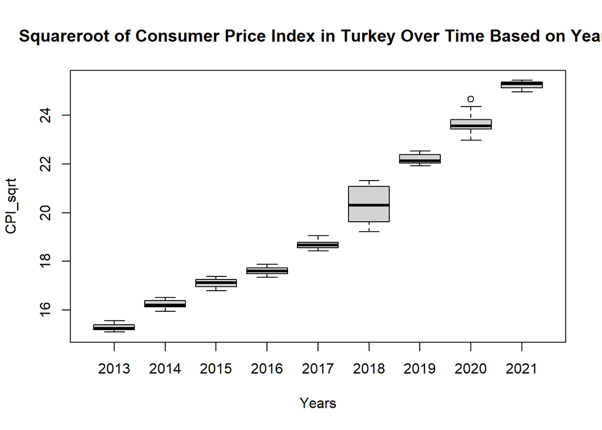

CPI Sqrt Box Plots in order to Observe Outliers

```
##       Date                 USD         Cons_Credit         Trust_Index
##  Min.   :2013-01-01   Min.   :1.764   Min.   :196419481   Min.   :77.05
##  1st Qu.:2015-01-16   1st Qu.:2.392   1st Qu.:285714994   1st Qu.:82.49
##  Median :2017-02-01   Median :3.512   Median :344273717   Median :89.66
##  Mean   :2017-01-30   Mean   :3.977   Mean   :370899867   Mean   :88.08
##  3rd Qu.:2019-02-15   3rd Qu.:5.692   3rd Qu.:409347210   3rd Qu.:92.55
##  Max.   :2021-03-01   Max.   :8.003   Max.   :689956886   Max.   :97.37
##
##  Interest_Rate_log    CPI_sqrt         month            trend           Year
##  Min.   :1.783     Min.   :15.10   Min.   : 1.000   Min.   : 1.0   2013   :12
##  1st Qu.:2.216     1st Qu.:16.84   1st Qu.: 3.000   1st Qu.:25.5   2014   :12
##  Median :2.336     Median :18.51   Median : 6.000   Median :50.0   2015   :12
##  Mean   :2.405     Mean   :19.08   Mean   : 6.364   Mean   :50.0   2016   :12
##  3rd Qu.:2.525     3rd Qu.:21.99   3rd Qu.: 9.000   3rd Qu.:74.5   2017   :12
##  Max.   :3.183     Max.   :25.42   Max.   :12.000   Max.   :99.0   2018   :12
##                                                                    (Other):27
```

The boxplot has been created in order to check outliers, however there is only one outlier seen in the figure, which may not generate a problem.

In order to get rid of high autocorrelation rate that have been observed in lag 1 and lag2, the below operations are performed and lag1 and lag2 lagged variables are included in the model.

```
##
## Call:
## lm(formula = CPI_sqrt ~ USD + Cons_Credit + Trust_Index + Interest_Rate_log +
##     as.factor(month) + lag1 + lag2 + trend, data = datatable_ts_log)
##
## Residuals:
##      Min       1Q   Median       3Q      Max
## -0.75768 -0.10580  0.00142  0.10708  0.45898
##
## Coefficients: (1 not defined because of singularities)
##                      Estimate Std. Error t value Pr(>|t|)
## (Intercept)         1.570e+01  7.390e-01  21.242  < 2e-16 ***
## USD                 7.943e-01  6.729e-02  11.804  < 2e-16 ***
## Cons_Credit         2.370e-09  7.391e-10   3.206 0.001933 **
## Trust_Index        -3.285e-02  7.705e-03  -4.264 5.46e-05 ***
## Interest_Rate_log   2.638e-01  9.739e-02   2.708 0.008265 **
## as.factor(month)2   9.571e-02  9.934e-02   0.963 0.338229
## as.factor(month)3   1.244e-01  9.900e-02   1.256 0.212640
## as.factor(month)4   9.511e-02  1.030e-01   0.923 0.358691
## as.factor(month)5  -1.578e-01  1.035e-01  -1.525 0.131117
## as.factor(month)6  -1.851e-01  1.028e-01  -1.801 0.075540 .
## as.factor(month)7  -2.643e-01  1.023e-01  -2.583 0.011628 *
## as.factor(month)8  -5.100e-01  1.025e-01  -4.978 3.62e-06 ***
## as.factor(month)9  -6.564e-01  1.021e-01  -6.427 8.72e-09 ***
## as.factor(month)10 -5.032e-01  1.020e-01  -4.934 4.31e-06 ***
## as.factor(month)11 -4.293e-01  1.020e-01  -4.208 6.70e-05 ***
## as.factor(month)12 -3.599e-01  1.019e-01  -3.532 0.000688 ***
## lag1                7.986e-01  7.227e-02  11.050  < 2e-16 ***
## lag2                       NA         NA      NA       NA
## trend               3.644e-02  2.904e-03  12.546  < 2e-16 ***
## ---
## Signif. codes:  0 '***' 0.001 '**' 0.01 '*' 0.05 '.' 0.1 ' ' 1
##
## Residual standard error: 0.2035 on 80 degrees of freedom
##   (1 observation deleted due to missingness)
## Multiple R-squared:  0.9961, Adjusted R-squared:  0.9952
## F-statistic:  1187 on 17 and 80 DF,  p-value: < 2.2e-16
```

We know have an even better Adjusted R Squared Rates = 0.9952, so we can say that Model 3 is relatively better than the first two models.

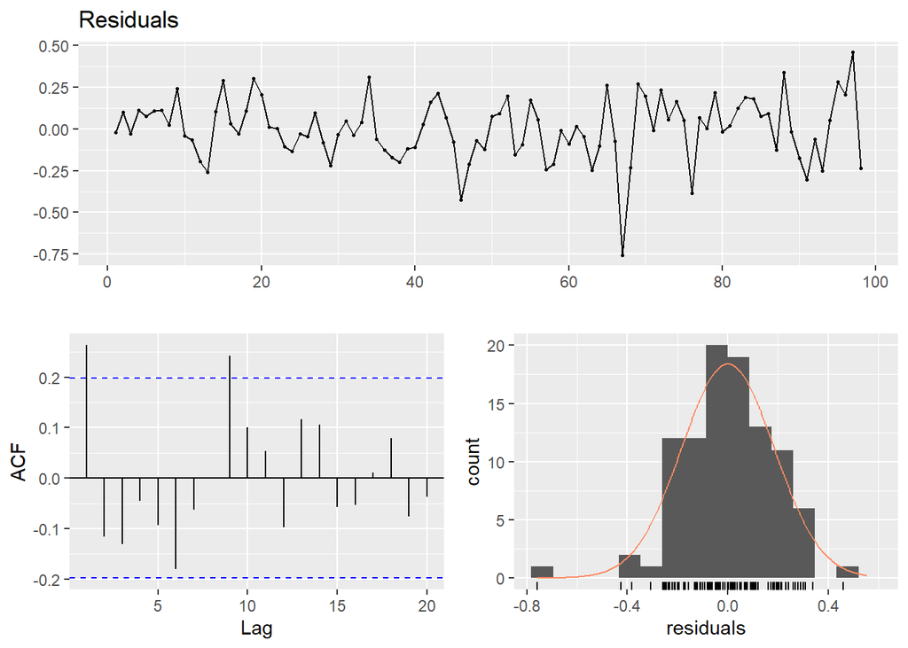

Residuals for Model 3

```
##
##  Breusch-Godfrey test for serial correlation of order up to 22
##
## data:  Residuals
## LM test = 41.655, df = 22, p-value = 0.006879
```

Looking at the residuals’ plots, residual errors have decreased with some peaks, residuals’ distribution shape fit have not significantly changed, also high ACF generally eliminated.

In order to eliminate high variations from mean 0 that have been observed in residuals, outliers of the residuals that fit the %95 and %5 quantiles have been detected, and included in the model 4 as dummy variables.

```
##
## Call:
## lm(formula = CPI_sqrt ~ USD + Cons_Credit + Trust_Index + Interest_Rate_log +
##     as.factor(month) + lag1 + lag2 + trend + Outliers_Down_Index +
##     Outliers_up_Index, data = datatable_log)
##
## Residuals:
##      Min       1Q   Median       3Q      Max
## -0.36847 -0.06627 -0.01040  0.09782  0.27619
##
## Coefficients: (1 not defined because of singularities)
##                       Estimate Std. Error t value Pr(>|t|)
## (Intercept)          1.609e+01  5.436e-01  29.598  < 2e-16 ***
## USD                  8.135e-01  4.884e-02  16.656  < 2e-16 ***
## Cons_Credit          2.153e-09  5.327e-10   4.042 0.000122 ***
## Trust_Index         -3.734e-02  5.648e-03  -6.611 4.09e-09 ***
## Interest_Rate_log    2.859e-01  7.035e-02   4.064 0.000113 ***
## as.factor(month)2    1.074e-01  7.099e-02   1.513 0.134161
## as.factor(month)3    1.238e-01  6.930e-02   1.787 0.077805 .
## as.factor(month)4    5.379e-02  7.261e-02   0.741 0.461064
## as.factor(month)5   -1.381e-01  7.360e-02  -1.876 0.064287 .
## as.factor(month)6   -1.801e-01  7.205e-02  -2.500 0.014484 *
## as.factor(month)7   -2.573e-01  7.182e-02  -3.583 0.000586 ***
## as.factor(month)8   -4.286e-01  7.490e-02  -5.722 1.81e-07 ***
## as.factor(month)9   -6.650e-01  7.147e-02  -9.305 2.47e-14 ***
## as.factor(month)10  -5.116e-01  7.144e-02  -7.161 3.67e-10 ***
## as.factor(month)11  -4.115e-01  7.280e-02  -5.653 2.41e-07 ***
## as.factor(month)12  -3.656e-01  7.160e-02  -5.106 2.22e-06 ***
## lag1                 7.996e-01  5.250e-02  15.231  < 2e-16 ***
## lag2                        NA         NA      NA       NA
## trend                3.554e-02  2.110e-03  16.845  < 2e-16 ***
## Outliers_Down_Index -4.856e-01  7.496e-02  -6.478 7.30e-09 ***
## Outliers_up_Index    3.381e-01  7.347e-02   4.602 1.57e-05 ***
## ---
## Signif. codes:  0 '***' 0.001 '**' 0.01 '*' 0.05 '.' 0.1 ' ' 1
##
## Residual standard error: 0.1469 on 79 degrees of freedom
## Multiple R-squared:  0.998,  Adjusted R-squared:  0.9975
## F-statistic:  2079 on 19 and 79 DF,  p-value: < 2.2e-16
```

In model 4, we obtained the highest Adjsted R-Squared Values so far, 0.9975. We can say that model 4 is relatively better than the first three models.

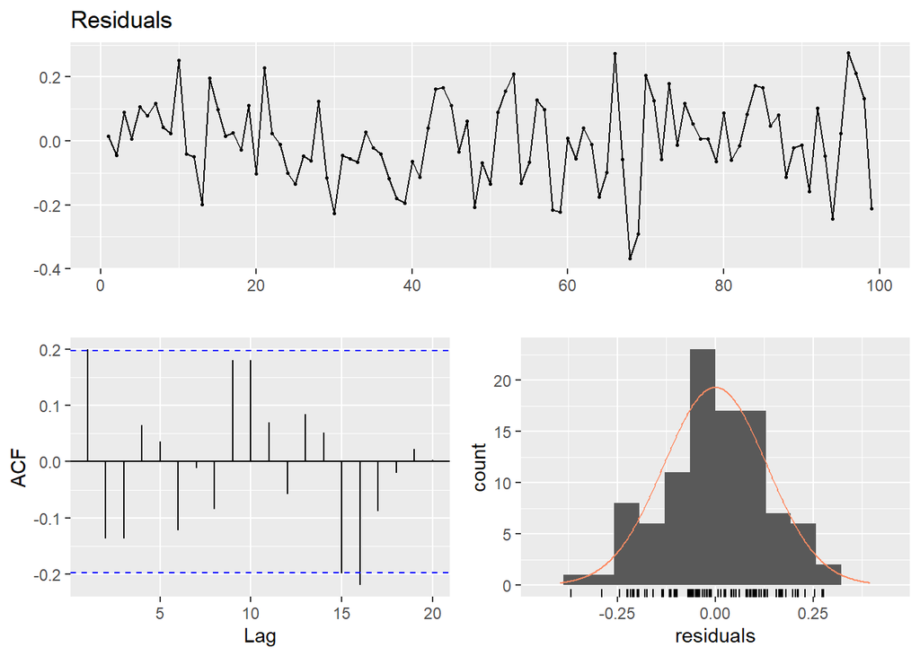

Residuals Model 4

```
##
##  Breusch-Godfrey test for serial correlation of order up to 24
##
## data:  Residuals
## LM test = 40.901, df = 24, p-value = 0.01708
```

## 1.3 Prediction

In this section, we inspect whether the model 4 could predict past data and also using this training if it could predict the future month’s CPI.

Looking at fitted vs residuals plot, residuals seem to be randomly distributed which what we wanted. Looking at the fitted vs CPI_sqrt plot and actual & Predicted CPI vs time plot, we can clearly see the correlation between them, which can conclude that this is a good model.

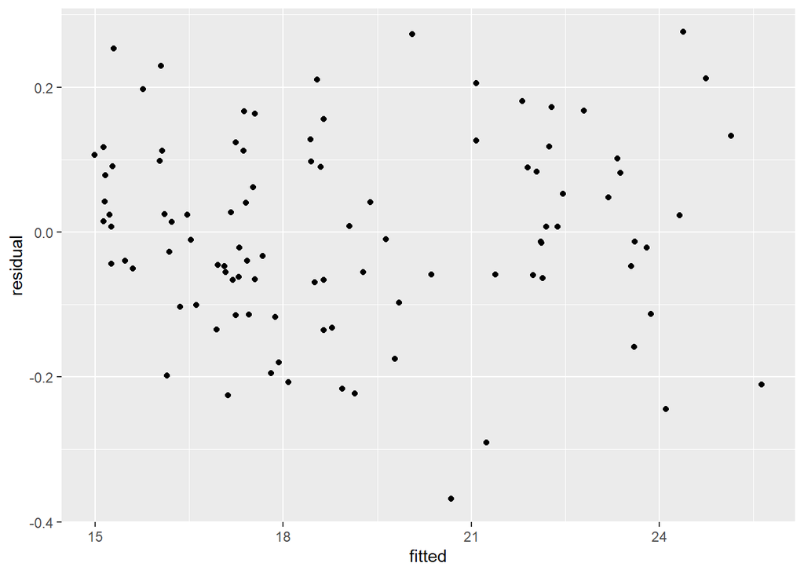

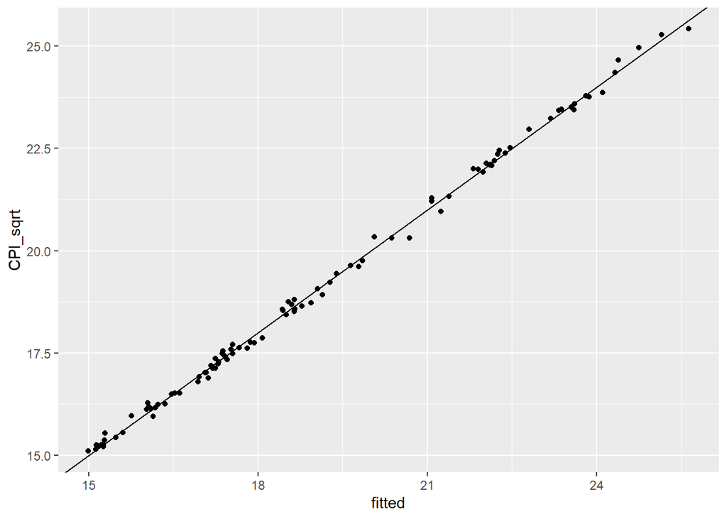

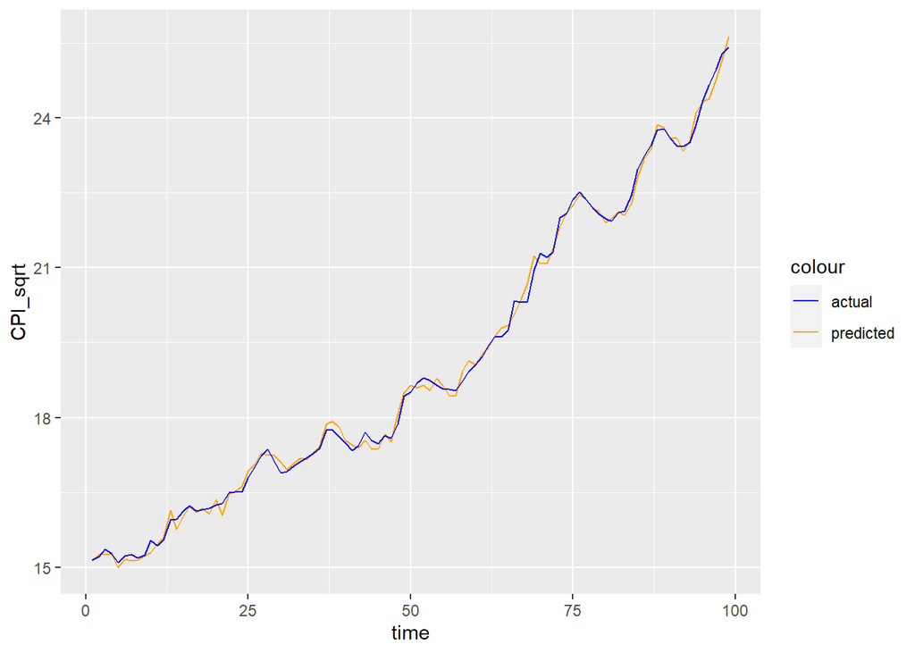